```
## 'data.frame':    42535 obs. of  5 variables:
##  $ good     : Factor w/ 2 levels "bad","good": 2 1 2 2 2 2 2 2 1 1 ...
##  $ purpose  : Factor w/ 8 levels "debt_consolidation",..: 1 4 7 6 6 8 1 4 7 6 ...
##  $ fico     : int  737 742 737 692 697 732 692 662 677 727 ...
##  $ loan_amnt: int  5000 2500 2400 10000 3000 5000 7000 3000 5600 5375 ...
##  $ income   : num  24000 30000 NA 49200 80000 36000 NA 48000 40000 15000 ...
```

Moreover, the output of the command summary is also given

```
##    good                     purpose           fico         loan_amnt
##  bad : 6371   debt_consolidation:25253   Min.   :612.0   Min.   :  500
##  good:36164   other             : 5160   1st Qu.:687.0   1st Qu.: 5200
##               major_purchase    : 3926   Median :712.0   Median : 9700
##               home_improvement  : 3625   Mean   :715.1   Mean   :11090
##               small_business    : 1992   3rd Qu.:742.0   3rd Qu.:15000
##               vacation_wedding  : 1404   Max.   :827.0   Max.   :35000
##               (Other)           : 1175
##      income
##  Min.   :   4800
##  1st Qu.:  44995
##  Median :  63000
##  Mean   :  75186
##  3rd Qu.:  90000
##  Max.   :6000000
##  NA's   :18758
```

The aim of the study is to analyze the potential relationship between the response variable good and the explanatory variables considered in the data frame, in order to evaluate the possible good/bad behaviour of a customer. Describe how to perform a preliminary data analysis on this data frame, using suitable R commands. Moreover, consider and discuss the following plots

Rimuoviamo i dati NA dal dataset

```r
loan <- loan[complete.cases(loan),]
summary(loan)
```

```
##    good                     purpose           fico         loan_amnt
##  bad : 3710   debt_consolidation:14721   Min.   :642.0   Min.   : 1000
##  good:20067   other             : 2471   1st Qu.:687.0   1st Qu.: 6500
##               home_improvement  : 2098   Median :712.0   Median :12000
##               major_purchase    : 1939   Mean   :715.2   Mean   :13216
##               small_business    : 1222   3rd Qu.:742.0   3rd Qu.:19000
##               vacation_wedding  :  808   Max.   :827.0   Max.   :35000
##               (Other)           :  518
##      income
##  Min.   :   4800
##  1st Qu.:  44995
##  Median :  63000
##  Mean   :  75186
##  3rd Qu.:  90000
##  Max.   :6000000
##
```

Distribuzione delle variabili

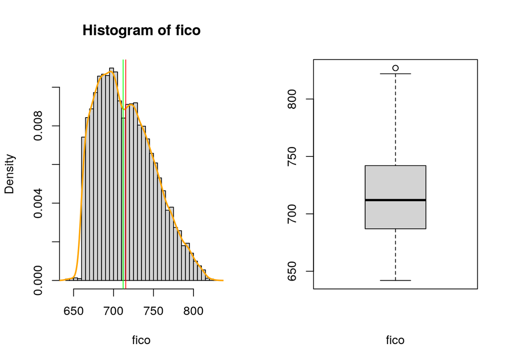

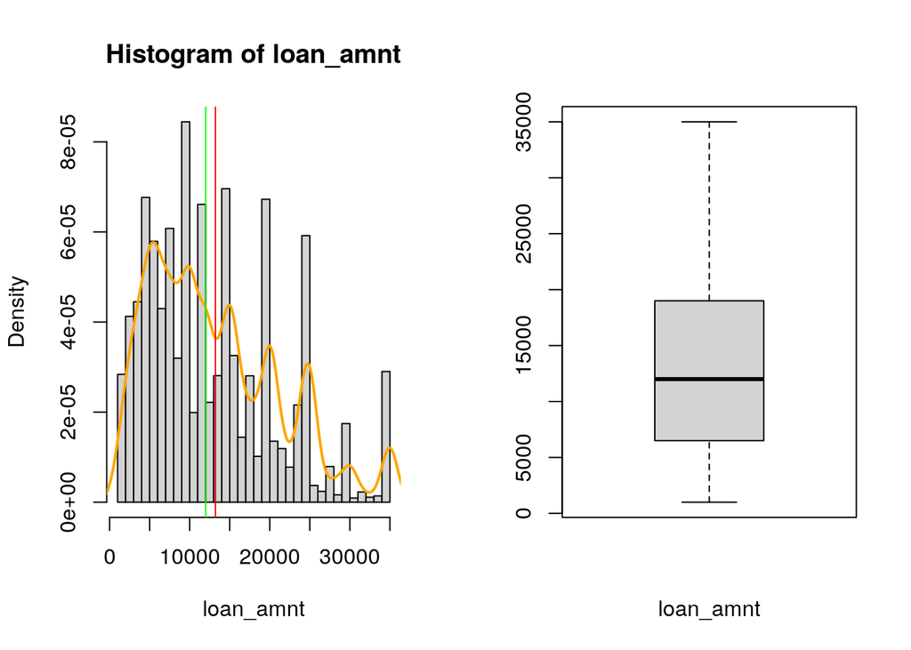

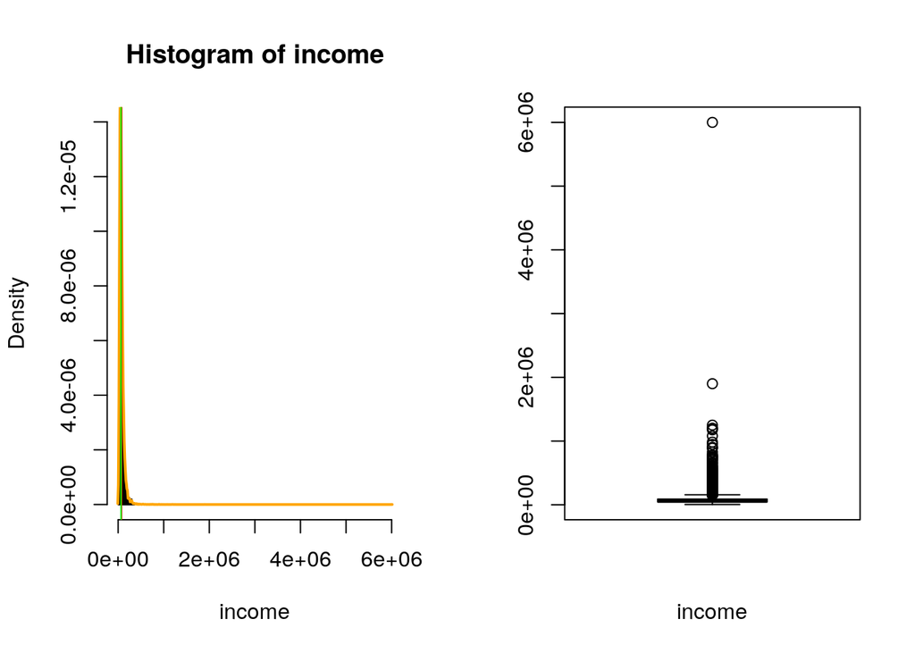

```
## [1] "Skewness indexes"
##       fico  loan_amnt     income
##  0.4862771  0.7476045 32.2344205
## [1] "Kurtosis indexes - 3"
##         fico    loan_amnt       income
##   -0.4971062   -0.0987338 2556.2477242
```

```r
source("./../functions.R", local = knitr::knit_global())

numeric.graph(loan, 3:5)
```

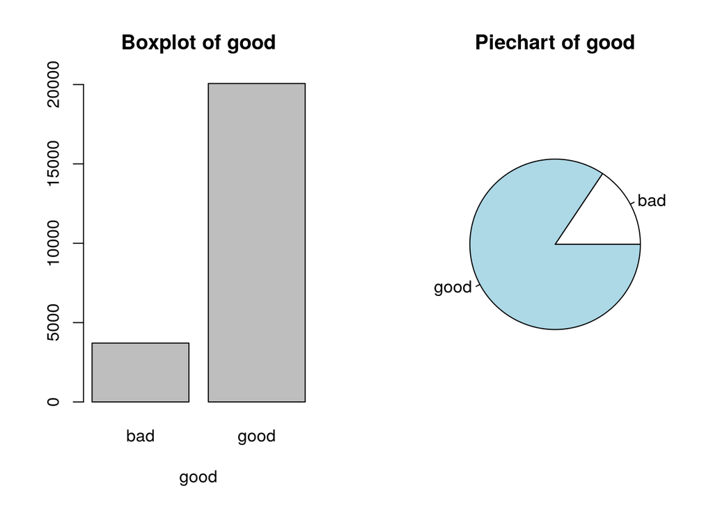

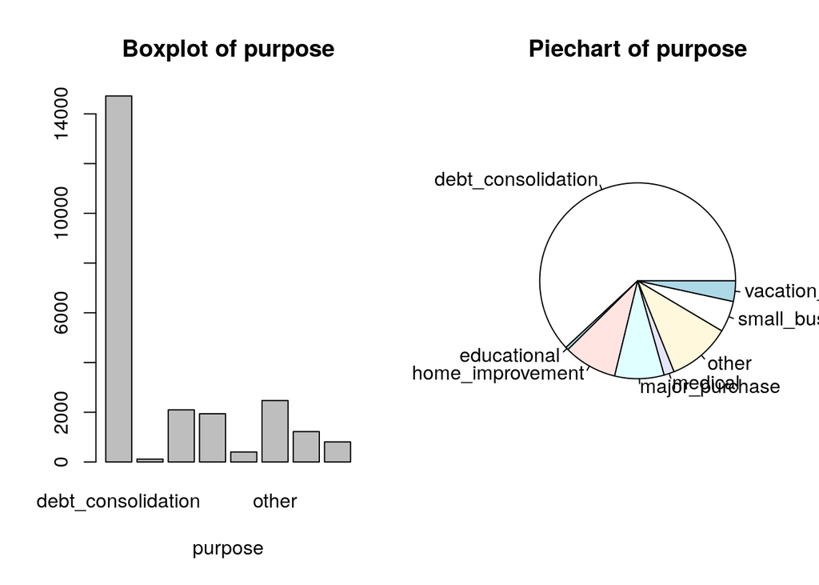

```r
categorical.graph(loan, 1:2)
```

Le variabili numeriche non sembrano seguire delle particolari distribuzioni. La variabile income presenta degli outlier molto grandi, per cui è necessario introdurre una trasformata.

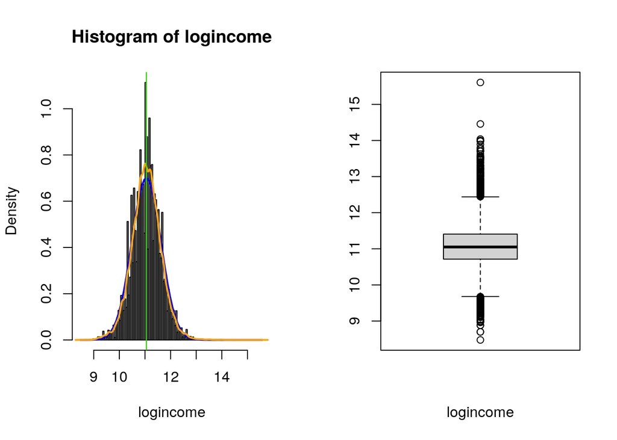

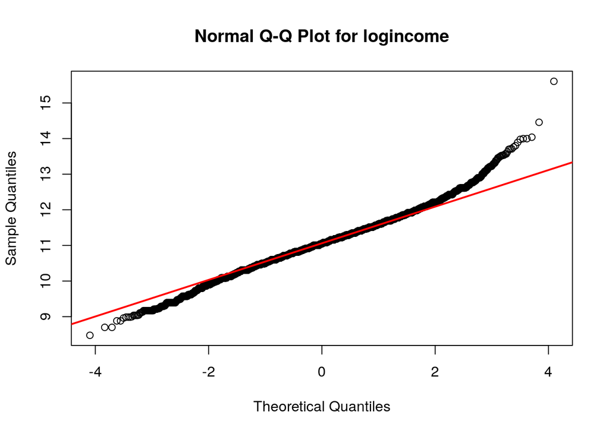

```
## [1] "Skewness indexes"
## [1] 0.1070414
## [1] "Kurtosis indexes - 3"
## [1] 1.051474
```

```r
loan$logincome <- log(loan$income)
numeric.graph(6, data = loan, qqplot = 6)
```

La trasformata logaritmica su income migliora notevolmente simmetria e curtosi restituendoci una campana ipernormale con una coda pesante a destra.

Dal punto delle variabili categoriali si nota la netta predominanza di un fattore su tutti gli altri (sia per good che per purpose).

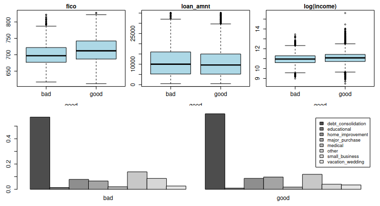

I grafici qui sopra mettono in correlazione la variabile risposta good con le altre variabili del dataset.

Le correlazioni tra le variabili numeriche sembrano essere molto deboli e fortemente influenzate dalla presenza di numerosi outliers.

Non sembrano esserci particolari correlazioni tra good e purpose, se non per alcuni particolari fattori.

In order to describe the effect of the factor fico on the response good we consider a simple logistic regression model fitted using the command `mod.1<-glm(good ∼ fico, data = loan, family = "binomial")`. Comment the model fitting outcomes given by the function summary and the output given by the subsequent commands.

```r
mod.1 <- glm(good ~ fico, data = loan, family = "binomial")
summary(mod.1)
```

```
##
## Call:
## glm(formula = good ~ fico, family = "binomial", data = loan)
##
## Deviance Residuals:
##     Min       1Q   Median       3Q      Max
## -2.4492   0.4317   0.5487   0.6411   0.8217
##
## Coefficients:
##               Estimate Std. Error z value Pr(>|z|)
## (Intercept) -6.3482496  0.3968152  -16.00   <2e-16 ***
## fico         0.0113094  0.0005614   20.15   <2e-16 ***
## ---
## Signif. codes:  0 '***' 0.001 '**' 0.01 '*' 0.05 '.' 0.1 ' ' 1
##
## (Dispersion parameter for binomial family taken to be 1)
##
##     Null deviance: 20592  on 23776  degrees of freedom
## Residual deviance: 20153  on 23775  degrees of freedom
## AIC: 20157
##
## Number of Fisher Scoring iterations: 4
```

```r
exp(coef(mod.1))
```

```
## (Intercept)        fico
## 0.001749807 1.011373636
```

```r
test <- data.frame(fico=c(700,750))
test$pred <- predict(mod.1,test, type="response")
test
```

```
##   fico      pred
## 1  700 0.8275497
## 2  750 0.8941483
```

```r
exp(coef(mod.1)[1])/1+exp(coef(mod.1)[1])
```

```
## (Intercept)
## 0.003499615
```

La funzione predict fornisce la probabilità di successo per due valori di fico: 700 e 750, rispettivamente del 83% e del 89% sulla base del modello.

Two further logistic regression models are fitted using `mod.2<-glm(good ∼ fico + loan_amnt, data = loan, family = "binomial")` and `mod.3<-glm(good ∼ fico + loan_amnt + income + purpose, data = loan, family = "binomial")`. Comment the corresponding output obtained by the R function summary and then suggest how to proceed with a further predictive analysis.

```r
mod.2 <- glm(good ~ fico + loan_amnt, data = loan, family = "binomial")
summary(mod.2)
```

```
##
## Call:
## glm(formula = good ~ fico + loan_amnt, family = "binomial", data = loan)
##
## Deviance Residuals:
##     Min       1Q   Median       3Q      Max
## -2.5772   0.4226   0.5431   0.6373   0.9171
##
## Coefficients:
##               Estimate Std. Error z value Pr(>|z|)
## (Intercept) -6.770e+00  4.026e-01 -16.813   <2e-16 ***
## fico         1.229e-02  5.764e-04  21.327   <2e-16 ***
## loan_amnt   -2.057e-05  2.190e-06  -9.394   <2e-16 ***
## ---
## Signif. codes:  0 '***' 0.001 '**' 0.01 '*' 0.05 '.' 0.1 ' ' 1
##
## (Dispersion parameter for binomial family taken to be 1)
##
##     Null deviance: 20592  on 23776  degrees of freedom
## Residual deviance: 20067  on 23774  degrees of freedom
## AIC: 20073
##
## Number of Fisher Scoring iterations: 4
```

Da questo modello risulta che tutti di due regressori numerici sono fortemente significativi, tuttavia gli incrementi (o decrementi) di probabilità sono molto contenuti.

```r
mod.3 <- glm(good ~ fico + loan_amnt + income + purpose, data = loan, family = "binomial")
summary(mod.3)
```

```
##
## Call:
## glm(formula = good ~ fico + loan_amnt + income + purpose, family = "binomial",
##     data = loan)
##
## Deviance Residuals:
##     Min       1Q   Median       3Q      Max
## -3.3659   0.3840   0.5224   0.6320   1.2589
##
## Coefficients:
##                           Estimate Std. Error z value Pr(>|z|)
## (Intercept)             -7.482e+00  4.119e-01 -18.165  < 2e-16 ***
## fico                     1.303e-02  5.906e-04  22.061  < 2e-16 ***
## loan_amnt               -3.663e-05  2.580e-06 -14.200  < 2e-16 ***
## income                   7.203e-06  5.426e-07  13.275  < 2e-16 ***
## purposeeducational      -5.076e-01  2.309e-01  -2.198   0.0279 *
## purposehome_improvement -1.077e-01  7.108e-02  -1.515   0.1298
## purposemajor_purchase    1.388e-02  7.689e-02   0.180   0.8568
## purposemedical          -2.678e-01  1.426e-01  -1.878   0.0604 .
## purposeother            -2.988e-01  6.034e-02  -4.952 7.34e-07 ***
## purposesmall_business   -9.158e-01  7.016e-02 -13.052  < 2e-16 ***
## purposevacation_wedding  1.114e-01  1.126e-01   0.989   0.3226
## ---
## Signif. codes:  0 '***' 0.001 '**' 0.01 '*' 0.05 '.' 0.1 ' ' 1
##
## (Dispersion parameter for binomial family taken to be 1)
##
##     Null deviance: 20592  on 23776  degrees of freedom
## Residual deviance: 19677  on 23766  degrees of freedom
## AIC: 19699
##
## Number of Fisher Scoring iterations: 5
```

Da questo modello risulta che non tutti i fattori di purpose sono significativi, e la maggior parte di questi hanno coefficiente negativo, in particolare l’attività più “a rischio” sembra essere small_business, seguita da educational. Non si rilevano confounding phenomena dovuti a correlazioni non rilevate.

Il valore dell’AIC fa preferire questo modello rispetto al precedente.

Verifichiamo quale dei due modelli è più accurato

```r
logitResponse.modelVerify(mod.2, response.var = 1)
```

```
## [1] "Il modello è corretto, tutti i fitted values sono compresi tra 0 e 1"
```

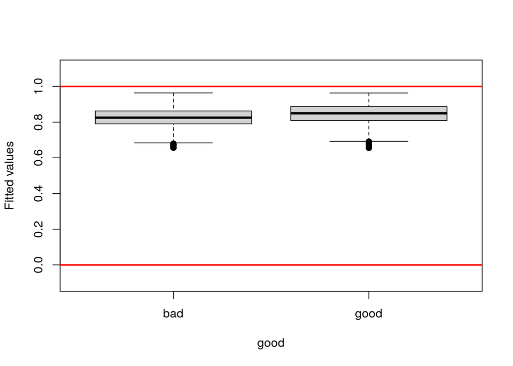

```
##
## Fold:  3 4 1 7 5 6 10 8 2 9
## Internal estimate of accuracy = 0.844
## Cross-validation estimate of accuracy = 0.844
```

```r
logitResponse.modelVerify(mod.3, response.var = 1)
```

```
## [1] "Il modello è corretto, tutti i fitted values sono compresi tra 0 e 1"
```

```
##
## Fold:  8
```

```
##  5
```

```
##  6
```

```
##  9
```

```
##  2
```

```
##  10
```

```
##  3
```

```
##  1 7
```

```
##  4
```

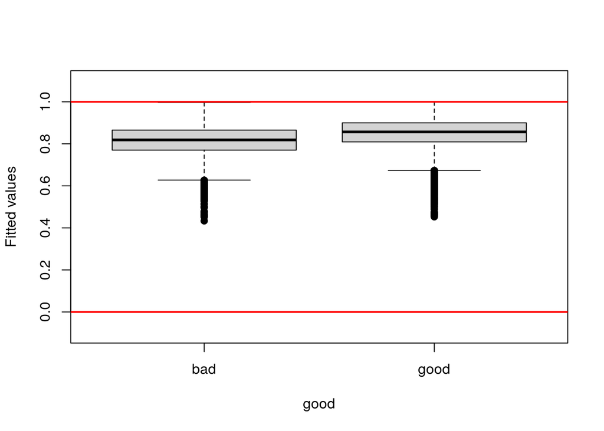

```
##
## Internal estimate of accuracy = 0.844
## Cross-validation estimate of accuracy = 0.844
```

Questo probabilmente è dovuto probabilmente alla struttura del dataset per cui si consiglia di inserire ulteriori dati nel dataset, in particolare casi per cui la variabile `good` assume valore negativo, oppure valutare una soglia di previsione alternativa con la curva ROC.

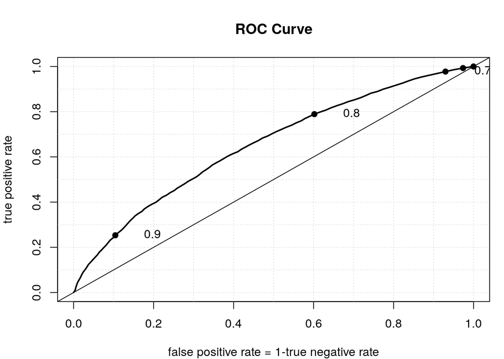

```
##                 tot. accuracy true negative true positive
## training data       0.8440510   0.003504043     0.9994518
## cross-validated     0.8439669   0.000000000     1.0000000
```

```r
logitResponse.modelVerify.verbose(glm.object = mod.3,
                                  response.var = 1,
                                  regressors = 2:4,
                                  data = loan,
                                  values = c("good", "bad"),
                                  roc = T)
```

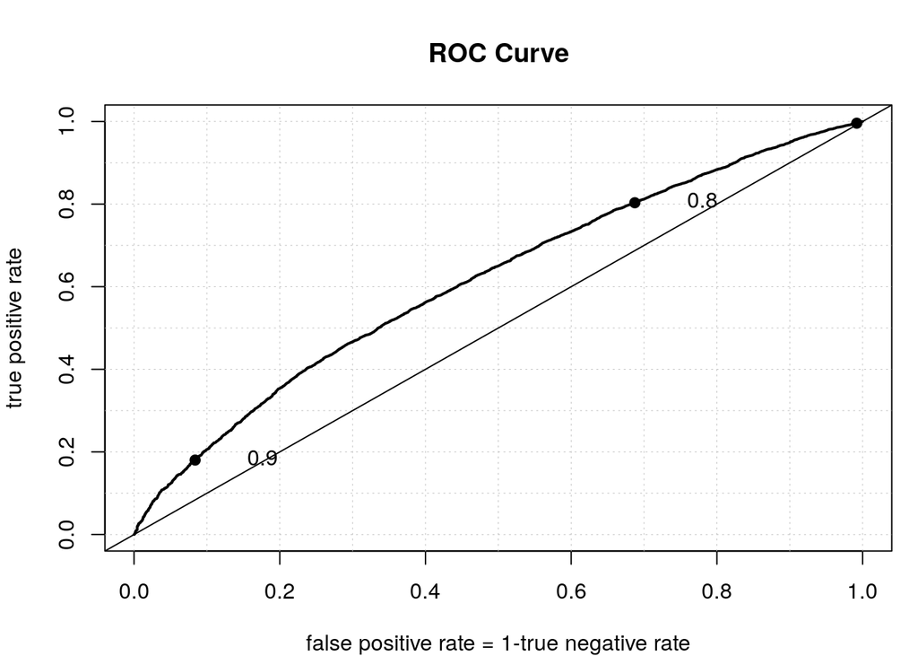

```
##                 tot. accuracy true negative true positive
## training data       0.8439669             0             1
## cross-validated     0.8439669             0             1
```

```r
logitResponse.modelVerify.verbose(glm.object = mod.2,
                                  response.var = 1,
                                  regressors = 2:4,
                                  data = loan,
                                  values = c("good", "bad"),
                                  roc = T)
```

Il confronto tra le curve ROC dei due modelli suggerisce l’utilizzo di `mod3`, oppure classificatori di altro tipo.